# Dimensionality reduction

This weeks material will focus on a set of statistical methods that fall under the term *dimensionality reduction*. In practice, dimensionality reduction is a way to recognize and visualize the dimensions that carry the most information from a multidimensional data by collecting as much variance as possible from the original variables. One of the most well-known methods in dimensionality reduction is **Principal Component Analysis (PCA)**. After we have recognized the principal components by a few matrix transformations, we can observe the components in a 2-dimensional space, which would not be possible without performing dimensionality reduction.

Another method we focus on is **Multiple correspondence analysis (MCA)**, with which we can find suitable transformations from classified variables to continuous scales and then reducing the dimensions with the PCA for visualization purposes.

**Task 5: Data wrangling**

Done, and the assignment is in the latter part of [this file](https://github.com/teemuvh/IODS-project/blob/master/data/create_human.R).

**Task 5: Analysis**

```r
library(dplyr)
human <- read.table("data/human.txt", sep = ",", header = T)
```

Now that we have wrangled the “human” data, we can start working on the analysis part. The data consists of 155 observations and 8 explanatory variables. These observations are designed to capture a wider representation of the development of a country than merely looking at the economic growth would do. Thus, the data includes variables related gender inequality, life expectancy, eduaction, *et cetera*. More information about the data can be obtained from [here](https://hdr.undp.org/data-center/human-development-index). The below figure provides a graphical overview of the data.

```r
library(GGally)
```

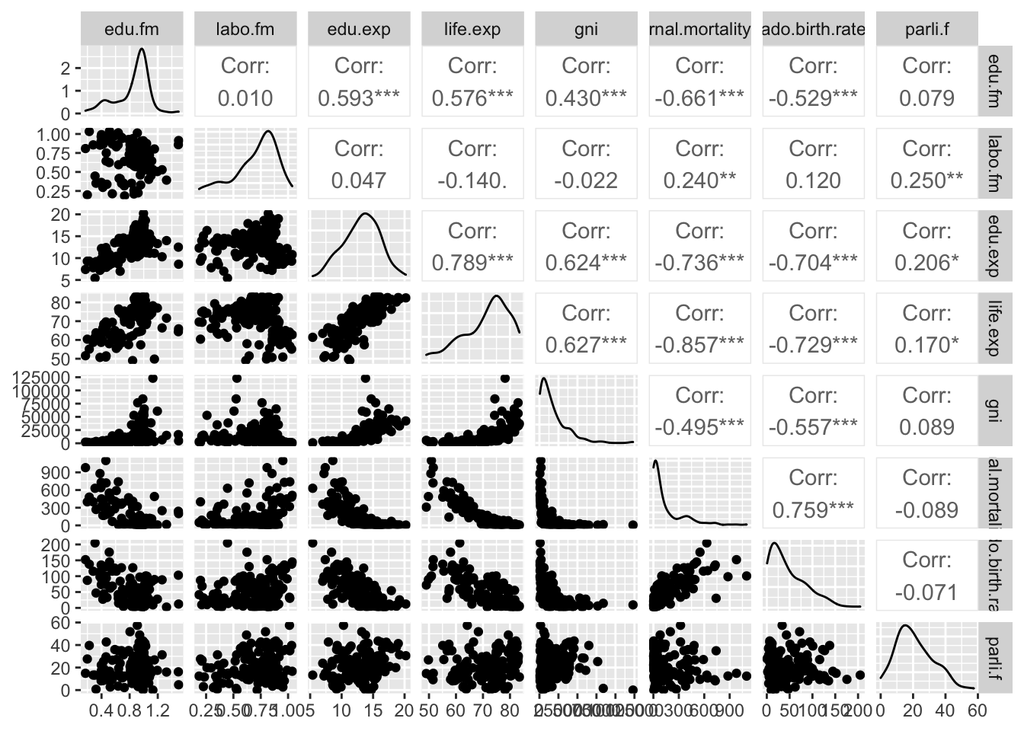

```r
ggpairs(human)
```

```r
summary(human)
```

```
##      edu.fm          labo.fm          edu.exp         life.exp
##  Min.   :0.1717   Min.   :0.1857   Min.   : 5.40   Min.   :49.00
##  1st Qu.:0.7264   1st Qu.:0.5984   1st Qu.:11.25   1st Qu.:66.30
##  Median :0.9375   Median :0.7535   Median :13.50   Median :74.20
##  Mean   :0.8529   Mean   :0.7074   Mean   :13.18   Mean   :71.65
##  3rd Qu.:0.9968   3rd Qu.:0.8535   3rd Qu.:15.20   3rd Qu.:77.25
##  Max.   :1.4967   Max.   :1.0380   Max.   :20.20   Max.   :83.50
##       gni         maternal.mortality.ratio ado.birth.rate      parli.f
##  Min.   :   581   Min.   :   1.0           Min.   :  0.60   Min.   : 0.00
##  1st Qu.:  4198   1st Qu.:  11.5           1st Qu.: 12.65   1st Qu.:12.40
##  Median : 12040   Median :  49.0           Median : 33.60   Median :19.30
##  Mean   : 17628   Mean   : 149.1           Mean   : 47.16   Mean   :20.91
##  3rd Qu.: 24512   3rd Qu.: 190.0           3rd Qu.: 71.95   3rd Qu.:27.95
##  Max.   :123124   Max.   :1100.0           Max.   :204.80   Max.   :57.50
```

From the above visualization, we can observe how the variables interact with each others in terms of Pearson correlation coefficient (right of the diagonal). For instance, if we consider adolescent birth rate (`ado.birth.rate`), we can easily see that it correlates strongly with the ratio of female and male education (`edu.fm`), as well as with expected years of education (`edu.exp`), life expectancy (`life.exp`), and GNI, and maternal mortality (`maternal.mortality.ratio`).

From the scatter plots (left of the diagonal), we can observe some correlation with the data points. For example, expected years of education (`edu.exp`) seems to positively correlate with life expectancy (`life.exp`). Similarly, for instance expected years of education seems to negatively correlate with maternal mortality.

These information are perhaps more easily visible from a heat map of correlations, represented in the figure below. In the heat map, the darker the color, the more correlation between the variables. Blue color indicates positive correlation, whereas red color indicates negative correlation. If we look at the variables discussed above, we notice that adolescent birth rate correlates rather strongly with the ratio of education (`edu.fm`), and even more with life expectany, for instance. If we consider expected years of education, we notice that it has a strong positive correlation with life expectancy, and a high negative correlation with maternal mortality. Thus, we can read that education increases the life expectancy, and decreases the maternal mortality.

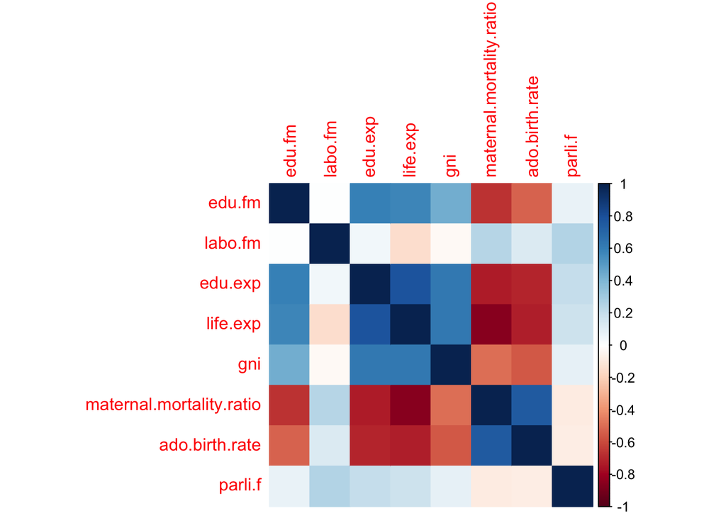

```r
library(corrplot)
cor(human) %>%
  corrplot(method="color")
```

Now that we have summarized and observed the data a little, we can move to dimensionality reduction.

PCA performs SVD-decomposition to find the principal components of the data. The first component will explain most of the variance, and the second component, which is orthogonal to the first component, will explain most of the variance after the first component has been removed. This way, we will obtain two dimensions, one represents principal component 1, and the second represents principal component 2.

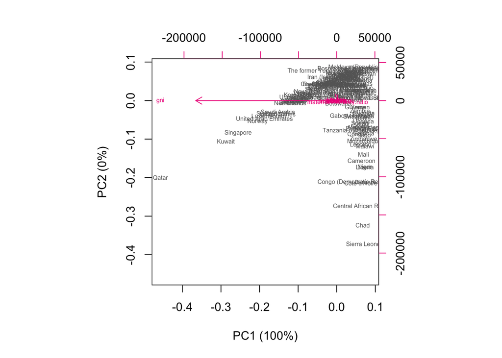

```r
# perform principal component analysis (with the SVD method)
pca_human <- prcomp(human, scale = FALSE)
pca_human_std <- prcomp(human, scale = TRUE)

sh <- summary(pca_human)
sh_std <- summary(pca_human_std)

pca_pr_sh <- round(100*sh$importance[2, ], digits = 1)
pca_pr_sh_std <- round(100*sh_std$importance[2, ], digits = 1)

pc_lab_sh <- paste0(names(pca_pr_sh), " (", pca_pr_sh, "%)")
pc_lab_sh_std <- paste0(names(pca_pr_sh_std), " (", pca_pr_sh_std, "%)")

# draw a biplot of the principal component representation and the original variables
biplot(pca_human,
       choices = 1:2,
       cex = c(0.5, 0.5),
       col = c("grey40", "deeppink2"),
       xlab = pc_lab_sh[1], ylab = pc_lab_sh[2]
       )
```

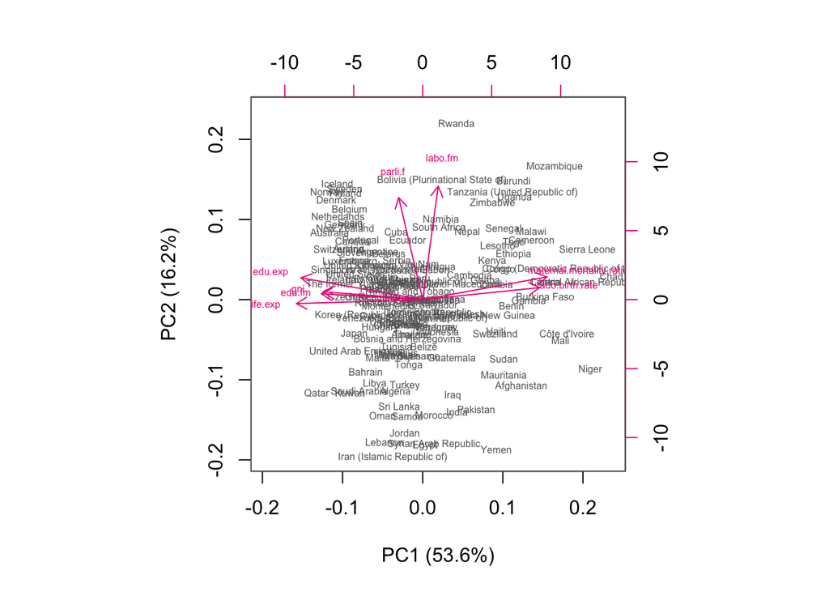

```r
biplot(pca_human_std,
       choices = 1:2,
       cex = c(0.5, 0.5),
       col = c("grey40", "deeppink2"),
       xlab = pc_lab_sh_std[1], ylab = pc_lab_sh_std[2],
       )
```

From the visualizations above, we can observe that it is necessary to standardize the data before applying PCA. As PCA aims to maximize the variance, non-standardized data can seem like some component dictates the variance, when, in truth, some other components might also contribute (first figure). After standardizing the data, the model can actually find the components that maximize the variance (second figure). This is also suggested by the values in the summaries of the PCA (below). Based on the proportion of variances explained by the different principal components, PCA suggests that the first principal component explains practically all of the variance in the non-standardized data. However, when we standardize the data, PCA suggests that the first principal component explains slightly more than half of the variance, whereas the second principal component explains approximately 16% of the variance.

```r
sh; sh_std
```

```
## Importance of components:
##                              PC1      PC2   PC3   PC4   PC5   PC6    PC7    PC8
## Standard deviation     1.854e+04 185.5219 25.19 11.45 3.766 1.566 0.1912 0.1591
## Proportion of Variance 9.999e-01   0.0001  0.00  0.00 0.000 0.000 0.0000 0.0000
## Cumulative Proportion  9.999e-01   1.0000  1.00  1.00 1.000 1.000 1.0000 1.0000
```

```
## Importance of components:
##                           PC1    PC2     PC3     PC4     PC5     PC6     PC7
## Standard deviation     2.0708 1.1397 0.87505 0.77886 0.66196 0.53631 0.45900
## Proportion of Variance 0.5361 0.1624 0.09571 0.07583 0.05477 0.03595 0.02634
## Cumulative Proportion  0.5361 0.6984 0.79413 0.86996 0.92473 0.96069 0.98702
##                            PC8
## Standard deviation     0.32224
## Proportion of Variance 0.01298
## Cumulative Proportion  1.00000
```

We can also attempt at interpreting the principal components. I focus on the PCA of the standardized data (second figure above). It seems that life expectancy, and expected years of education (as well as the ratio between male and female expected education) increase in the countries clustered to the left of the space. Similarly, the number of female representatives in the parliament seems to increase to the top left corner of the space. Many countries in the left side of the space seem to be European or East Asian, but there are also a couple of rich countries from the Arabian peninsula. Countries in the top left corner of the space seem to be mostly Scandinavian countries. Countries clustered on right end of the space seem to be mostly from the African continent. In these countries, maternal mortality seems to be high, with also high adolescence birth rate, the two being phenomena that probably go hand in hand.

Finally, my personal interpretation of the first two principal components of the standardized dataset: the first principal component seems to represent life expectancy, and variables that correspond to life expectancy. The second principal component seems to somewhat represent gender inequality.

#### Tea data

In the final part of this exercise, we investigate a dataset that consists of answers to a questionnaire about tea consumption.

```r
tea <- read.table("https://raw.githubusercontent.com/KimmoVehkalahti/Helsinki-Open-Data-Science/master/datasets/tea.csv",
                  sep = ",", header = T)
```

```r
str(tea); dim(tea)
```

```
## 'data.frame':    300 obs. of  36 variables:
##  $ breakfast       : chr  "breakfast" "breakfast" "Not.breakfast" "Not.breakfast" ...
##  $ tea.time        : chr  "Not.tea time" "Not.tea time" "tea time" "Not.tea time" ...
##  $ evening         : chr  "Not.evening" "Not.evening" "evening" "Not.evening" ...
##  $ lunch           : chr  "Not.lunch" "Not.lunch" "Not.lunch" "Not.lunch" ...
##  $ dinner          : chr  "Not.dinner" "Not.dinner" "dinner" "dinner" ...
##  $ always          : chr  "Not.always" "Not.always" "Not.always" "Not.always" ...
##  $ home            : chr  "home" "home" "home" "home" ...
##  $ work            : chr  "Not.work" "Not.work" "work" "Not.work" ...
##  $ tearoom         : chr  "Not.tearoom" "Not.tearoom" "Not.tearoom" "Not.tearoom" ...
##  $ friends         : chr  "Not.friends" "Not.friends" "friends" "Not.friends" ...
##  $ resto           : chr  "Not.resto" "Not.resto" "resto" "Not.resto" ...
##  $ pub             : chr  "Not.pub" "Not.pub" "Not.pub" "Not.pub" ...
##  $ Tea             : chr  "black" "black" "Earl Grey" "Earl Grey" ...
##  $ How             : chr  "alone" "milk" "alone" "alone" ...
```

[output cut: 22 more lines]

```
## [1] 300  36
```

All the variables are categorical. Thus, we need to convert them all to factors.

```r
col_names <- names(tea)
tea[,col_names] <- lapply(tea[,col_names] , factor)

str(tea)
```

```
## 'data.frame':    300 obs. of  36 variables:
##  $ breakfast       : Factor w/ 2 levels "breakfast","Not.breakfast": 1 1 2 2 1 2 1 2 1 1 ...
##  $ tea.time        : Factor w/ 2 levels "Not.tea time",..: 1 1 2 1 1 1 2 2 2 1 ...
##  $ evening         : Factor w/ 2 levels "evening","Not.evening": 2 2 1 2 1 2 2 1 2 1 ...
##  $ lunch           : Factor w/ 2 levels "lunch","Not.lunch": 2 2 2 2 2 2 2 2 2 2 ...
##  $ dinner          : Factor w/ 2 levels "dinner","Not.dinner": 2 2 1 1 2 1 2 2 2 2 ...
##  $ always          : Factor w/ 2 levels "always","Not.always": 2 2 2 2 1 2 2 2 2 2 ...
##  $ home            : Factor w/ 2 levels "home","Not.home": 1 1 1 1 1 1 1 1 1 1 ...
##  $ work            : Factor w/ 2 levels "Not.work","work": 1 1 2 1 1 1 1 1 1 1 ...
##  $ tearoom         : Factor w/ 2 levels "Not.tearoom",..: 1 1 1 1 1 1 1 1 1 2 ...
##  $ friends         : Factor w/ 2 levels "friends","Not.friends": 2 2 1 2 2 2 1 2 2 2 ...
##  $ resto           : Factor w/ 2 levels "Not.resto","resto": 1 1 2 1 1 1 1 1 1 1 ...
##  $ pub             : Factor w/ 2 levels "Not.pub","pub": 1 1 1 1 1 1 1 1 1 1 ...
##  $ Tea             : Factor w/ 3 levels "black","Earl Grey",..: 1 1 2 2 2 2 2 1 2 1 ...
##  $ How             : Factor w/ 4 levels "alone","lemon",..: 1 3 1 1 1 1 1 3 3 1 ...
```

[output cut: 22 more lines]

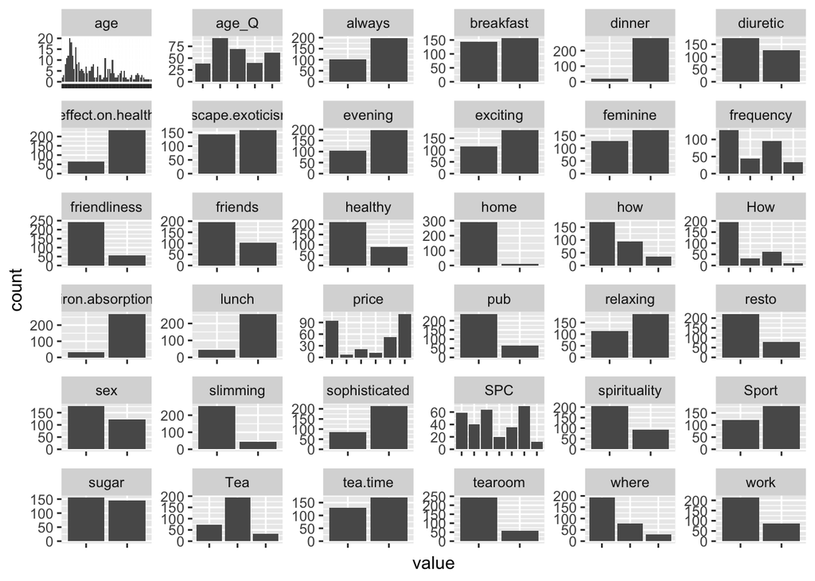

```r
# visualize the dataset
library(dplyr)
library(tidyr)
library(ggplot2)

vis <- pivot_longer(tea, cols = everything()) %>%
  ggplot(aes(value)) +
  facet_wrap("name", scales = "free") +
  geom_bar() +
  theme(axis.text.x = element_text(angle = 45, hjust = 1, size = 0))

vis
```

I somehow could not fit the visualization of all the variables in this page so that they would include the labels for the bars. Thus, I select a few of the variables and plot them again with the labels. These selected variables are also used for MCA soon.

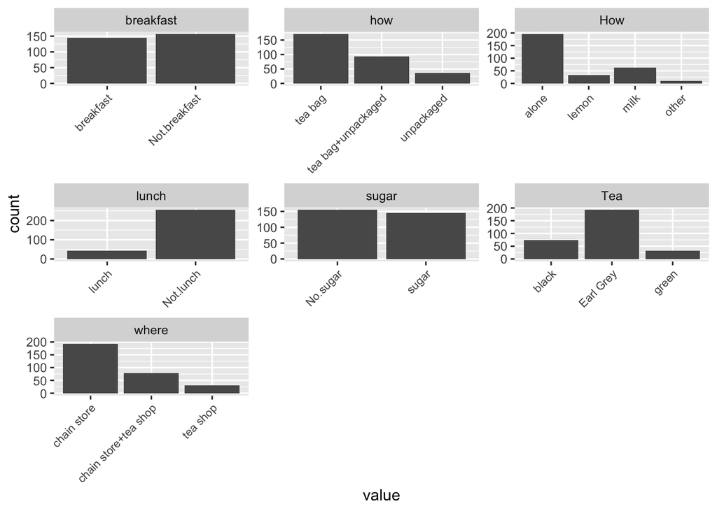

```r
library(dplyr)
library(tidyr)
library(ggplot2)

# column names to keep in the dataset
keep <- c("Tea", "How", "how", "sugar", "where", "lunch", "breakfast")

# select the 'keep_columns' to create a new dataset
tea_time <- dplyr::select(tea, one_of(keep))

# visualize the dataset
vis_ <- pivot_longer(tea_time, cols = everything()) %>%
  ggplot(aes(value)) +
  facet_wrap("name", scales = "free") +
  geom_bar() +
  theme(axis.text.x = element_text(angle = 45, hjust = 1, size = 8))

vis_
```

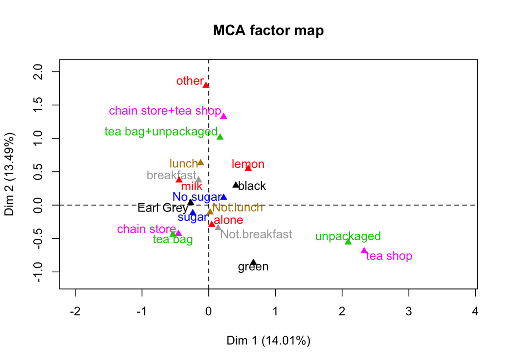

```r
library(FactoMineR)

mca <- MCA(tea_time, graph = FALSE)

# visualize MCA
plot(mca, invisible=c("ind"), graph.type = "classic", habillage = "quali")
```